# 2018_09_12_Chang_Weng

```r
library(pheatmap)
library(edgeR)
library(DESeq2)
library(biomaRt)
library(ggplot2)
```

Friday, September 7, 2018 WT73M_readcount Bred WT WT58M_readcount Bred WT WT973M_readcount Bred WT KO87M_readcount Bred KO KO56M_readcount Bred KO KO972M_readcount Bred KO WT112M_readcount Virus WT WT113M_readcount Virus WT WT114M_readcount Virus WT KO116M_readcount Virus KO KO117M_readcount Virus KO KO119M_readcount Virus KO

```r
#library(readxl)
setwd("~/Documents/chang/")
#originaldata = read_excel("gene_list/gene.description.xls", sheet="gene.description") #disappointed this didn't work
                         #need to download the developer version to see if that works
#devtools::install_version("readxl", version = "1.0.0")
#https://github.com/tidyverse/readxl/issues/466
```

Read in read counts for each sample taken from gene.description.xls

```r
filename = "readcounts.txt"
counts1 = read.table(filename, header = T, stringsAsFactors = F)
rownames(counts1) = counts1$geneID
```

Rename samples according to Yun’s instructions

```r
counts2 = counts1[,grep("readcount", colnames(counts1))]
sample_names = list(
  "WT73M_readcount" = "Bred_WT_rep1"
, "WT58M_readcount" = "Bred_WT_rep2"
, "WT973M_readcount" = "Bred_WT_rep3"
, "KO87M_readcount" = "Bred_KO_rep1"
, "KO56M_readcount" = "Bred_KO_rep2"
, "KO972M_readcount" = "Bred_KO_rep3"
, "WT112M_readcount" = "Virus_WT_rep1"
, "WT113M_readcount" = "Virus_WT_rep2"
, "WT114M_readcount" = "Virus_WT_rep3"
, "KO116M_readcount" = "Virus_KO_rep1"
, "KO117M_readcount" = "Virus_KO_rep2"
, "KO119M_readcount" = "Virus_KO_rep3"
)
colnames(counts2) = unlist(lapply (colnames(counts2), function(x) sample_names[[x]]))
colnames(counts2)
```

```
##  [1] "Bred_WT_rep1"  "Bred_WT_rep2"  "Bred_WT_rep3"  "Bred_KO_rep1"
##  [5] "Bred_KO_rep2"  "Bred_KO_rep3"  "Virus_WT_rep1" "Virus_WT_rep2"
##  [9] "Virus_WT_rep3" "Virus_KO_rep1" "Virus_KO_rep2" "Virus_KO_rep3"
```

Normally ilter out genes with low and high counts ( high counts might be mitochondrial genes)

```r
#data in table has probably already been filtered so keep all rows in this case
#keep = rowMeans(counts2) > 5 & rowMeans(counts2) < 5000
#keep = seq(1, nrow(counts2))
#if adjust p-values are NA then they probably removed that gene when testing for DE
keep = !(is.na(counts1$padj.KO_bredvsWT_bred.) | is.na(counts1$padj.KO_virusvsWT_virus.))
counts3 = counts2[keep,]
dim(counts2)
```

```
## [1] 35275    12
```

```r
dim(counts3)
```

```
## [1] 13102    12
```

```r
y <- DGEList(counts=counts3)
#fpkm_log_matrix = rpkm (y, gene.length=counts1[keep,"GeneLength"], log = TRUE)
fpkm_log_matrix = rpkm (y, gene.length=counts1[keep,"GeneLength"], log = FALSE)
```

Dendrogram

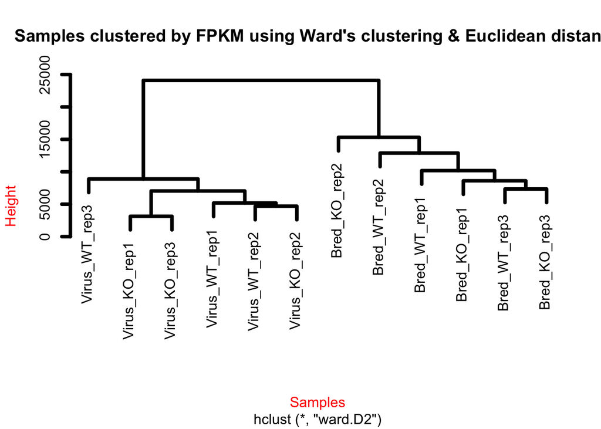

```r
#
#par(cex=1,font=3)
hc2 <- hclust(stats::dist(t(fpkm_log_matrix), method="minkowski"), "ward.D2")
#par(mar=c(10, 4, 4, 10), pty='s')
plot(hc2, lwd=4, lty=1, col="black", col.lab="red", xlab="Samples", main="Samples clustered by FPKM using Ward's clustering & Euclidean distance")
```

```r
Condition1 = factor(matrix (unlist(strsplit(colnames(counts3), "_")), byrow=T, ncol=3)[,1], levels = c("Bred", "Virus"))
Condition2 = factor(matrix (unlist(strsplit(colnames(counts3), "_")), byrow=T, ncol=3)[,2], levels = c("KO", "WT"))
Condition2 = relevel(Condition2, ref="WT")
cold <- data.frame("Condition1"=Condition1, "Condition2"=Condition2)
rownames(cold) = colnames(counts3)
cold
```

```
##               Condition1 Condition2
## Bred_WT_rep1        Bred         WT
## Bred_WT_rep2        Bred         WT
## Bred_WT_rep3        Bred         WT
## Bred_KO_rep1        Bred         KO
## Bred_KO_rep2        Bred         KO
## Bred_KO_rep3        Bred         KO
## Virus_WT_rep1      Virus         WT
## Virus_WT_rep2      Virus         WT
## Virus_WT_rep3      Virus         WT
## Virus_KO_rep1      Virus         KO
## Virus_KO_rep2      Virus         KO
## Virus_KO_rep3      Virus         KO
```

```r
ddsMat <- DESeq2::DESeqDataSetFromMatrix(countData=counts3, colData=cold, design=~Condition1 + Condition2);
colnames(ddsMat) <- colnames(counts3)
rld <- DESeq2::rlog(ddsMat) # LOG TRANSFORMED.
#rld <- DESeq2::rlog(ddsMat, blind=blind_status)
```

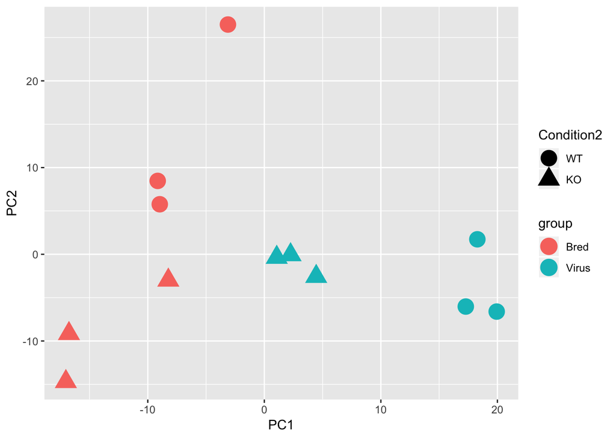

```r
pca              <- prcomp(t(assay(rld)))
#barplot(allPer.vec, main="PCA: % variance explained by each component\n" , ylim=c(0,100), names.arg=allPerLabels.vec)

d <- data.frame(pca$x, group=Condition1, Condition2, name=colnames(rld)) # returns PC1, PC2, ... PC8... etc
ppp <- ggplot(d, aes_string(x="PC1", y="PC2", shape="Condition2", color="group"))
ppp <- ppp + geom_point(size=6)
plot(ppp)
```

Heatmap to see how cells cluster by cell type or experimental condition.

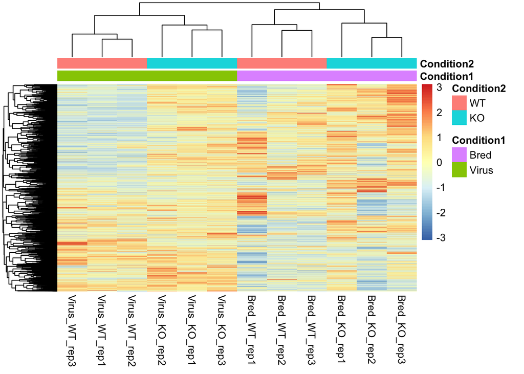

```r
HEATMAP_HEIGHT <- 45 # inchescol
HEATMAP_WIDTH  <- 15
annotation <- data.frame(
  Condition1= Condition1, Condition2=Condition2)
rownames(annotation) <- colnames(fpkm_log_matrix)
pheatmap(fpkm_log_matrix,
         , width=HEATMAP_WIDTH, height=HEATMAP_HEIGHT
         , scale="row"  # actually scale each row
         , clustering_distance_rows="correlation" # or: euclidean
         , clustering_distance_cols="correlation"
         , clustering_method="complete"
         , display_numbers=FALSE
         , border_color="#00000000" # note: the last two digits here are the alpha channel/ transparency
         , show_rownames=FALSE, show_colnames = TRUE
         , annotation = annotation
         , fontsize_row=3.5)
```

Virus: Fit the model and estimate dispersion value.

```r
Virus_cols = grep ("Virus", colnames(counts3))
design_matrix_virus <- model.matrix( ~ Condition2[Virus_cols])
colnames(design_matrix_virus)
```

```
## [1] "(Intercept)"              "Condition2[Virus_cols]KO"
```

```r
design_matrix_virus
```

```
##   (Intercept) Condition2[Virus_cols]KO
## 1           1                        0
## 2           1                        0
## 3           1                        0
## 4           1                        1
## 5           1                        1
## 6           1                        1
## attr(,"assign")
## [1] 0 1
## attr(,"contrasts")
## attr(,"contrasts")$`Condition2[Virus_cols]`
## [1] "contr.treatment"
```

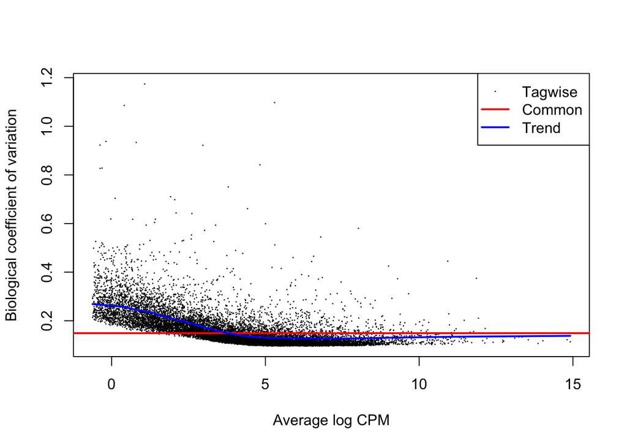

```r
y_for_DE_virus <- DGEList(counts=counts3[, Virus_cols])
y_for_DE_virus <- calcNormFactors(y_for_DE_virus)
y_for_DE_virus = estimateDisp(y_for_DE_virus, design=design_matrix_virus)
plotBCV(y_for_DE_virus)
```

```r
fit_virus <- glmFit(y_for_DE_virus, design=design_matrix_virus, dispersion=y_for_DE_virus$trended.dispersion)
```

Bred: Fit the model and estimate dispersion value.

```r
Bred_cols = grep ("Bred", colnames(counts3))
design_matrix_bred <- model.matrix( ~ Condition2[Bred_cols])
colnames(design_matrix_bred)
```

```
## [1] "(Intercept)"             "Condition2[Bred_cols]KO"
```

```r
design_matrix_bred
```

```
##   (Intercept) Condition2[Bred_cols]KO
## 1           1                       0
## 2           1                       0
## 3           1                       0
## 4           1                       1
## 5           1                       1
## 6           1                       1
## attr(,"assign")
## [1] 0 1
## attr(,"contrasts")
## attr(,"contrasts")$`Condition2[Bred_cols]`
## [1] "contr.treatment"
```

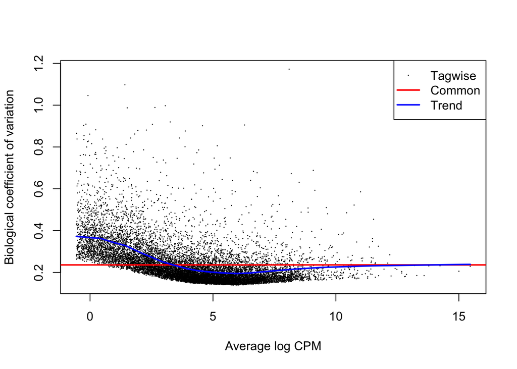

```r
y_for_DE_bred <- DGEList(counts=counts3[, Bred_cols])
y_for_DE_bred <- calcNormFactors(y_for_DE_bred)
y_for_DE_bred = estimateDisp(y_for_DE_bred, design=design_matrix_bred)
plotBCV(y_for_DE_bred)
```

```r
fit_bred <- glmFit(y_for_DE_bred, design=design_matrix_bred, dispersion=y_for_DE_bred$trended.dispersion)
```

Virus: KO vs WT

```r
lrt_virus <- glmLRT(fit_virus,coef = "Condition2[Virus_cols]KO")
topTags(lrt_virus)
```

```
## Coefficient:  Condition2[Virus_cols]KO
##                        logFC   logCPM       LR        PValue           FDR
## ENSMUSG00000020429 -5.251629 9.297705 792.5970 2.195867e-174 2.877025e-170
## ENSMUSG00000050423 -7.737949 4.418417 697.8450 8.796946e-154 5.762879e-150
## ENSMUSG00000031762 -2.798958 8.242602 294.3328  5.655912e-66  2.470125e-62
## ENSMUSG00000078650 -2.781978 6.850200 293.0814  1.059643e-65  3.470859e-62
## ENSMUSG00000028655 -3.720799 3.746178 266.5217  6.501467e-60  1.703644e-56
## ENSMUSG00000040152 -2.666512 5.515477 247.2901  1.012129e-55  2.210153e-52
## ENSMUSG00000038894 -2.427120 5.902090 217.5344  3.120436e-49  5.840565e-46
## ENSMUSG00000029272 -3.463858 3.380677 203.4877  3.620424e-46  5.929349e-43
## ENSMUSG00000042622 -2.318742 5.790621 198.3147  4.870965e-45  7.091043e-42
## ENSMUSG00000020593 -2.189617 7.109330 193.1866  6.409193e-44  8.397325e-41
```

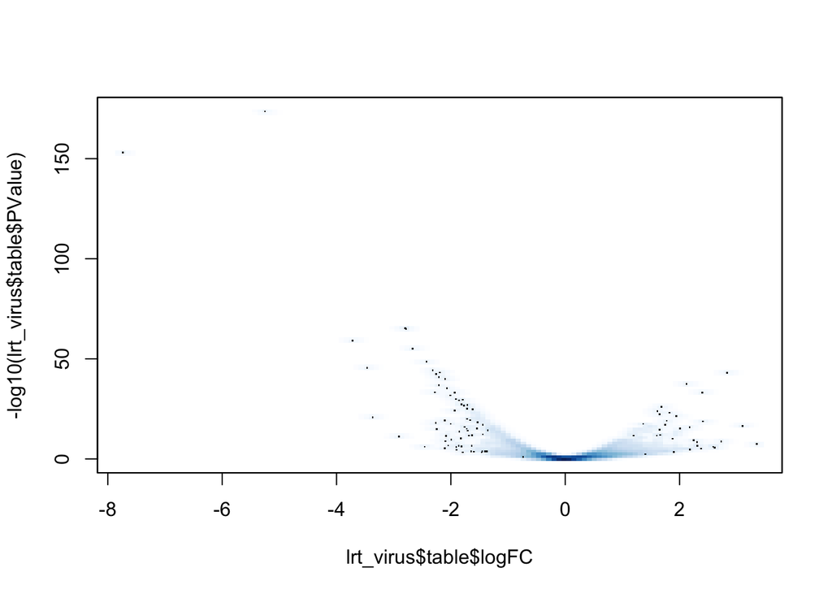

```r
smoothScatter(x=lrt_virus$table$logFC, y=-log10(lrt_virus$table$PValue))
```

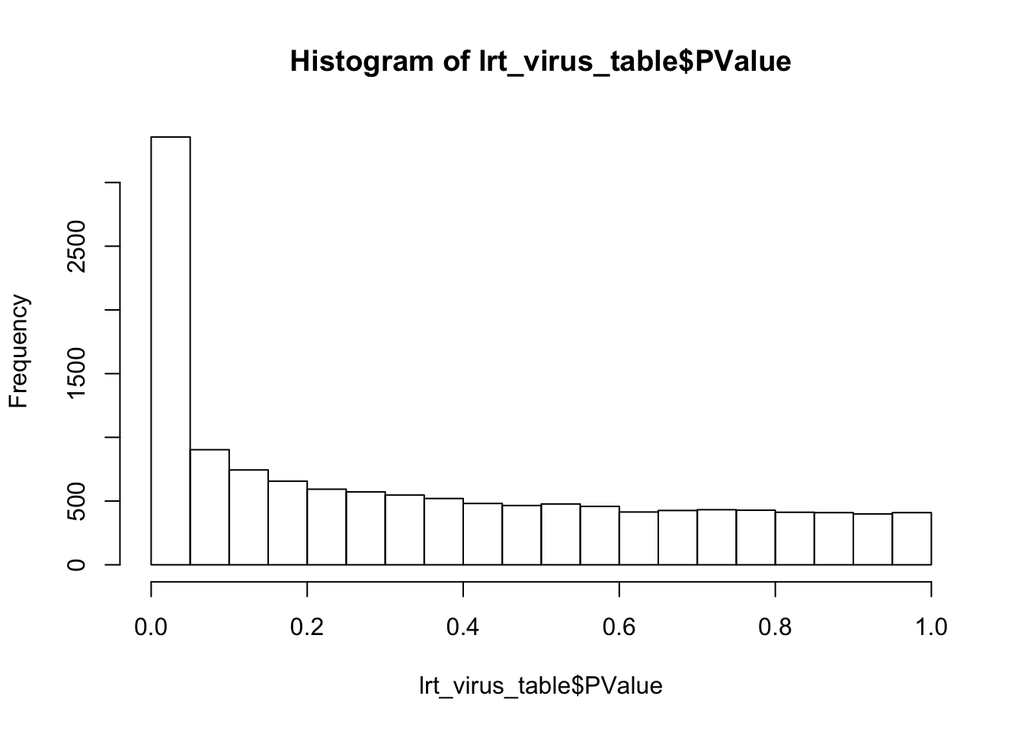

```r
lrt_virus_table = data.frame(lrt_virus$table, p.adjust(lrt_virus$table$PValue, method = "BH"))
colnames(lrt_virus_table) = c(colnames(lrt_virus$table), "adjPVal_BH")
hist(lrt_virus_table$PValue)
```

Bred: KO vs WT

```r
lrt_bred <- glmLRT(fit_bred,coef = "Condition2[Bred_cols]KO")
topTags(lrt_bred)
```

```
## Coefficient:  Condition2[Bred_cols]KO
##                        logFC    logCPM        LR       PValue          FDR
## ENSMUSG00000029272  6.215499  5.080030 367.60960 6.203882e-82 8.128327e-78
## ENSMUSG00000066071 -4.394531  6.804435 253.93477 3.602889e-57 2.360253e-53
## ENSMUSG00000052974 -2.953362  7.794927 121.13141 3.576395e-28 1.561931e-24
## ENSMUSG00000066154 -2.779383  7.121923 115.57545 5.887600e-27 1.928483e-23
## ENSMUSG00000078672 -3.131308 10.740377 114.35249 1.090868e-26 2.858510e-23
## ENSMUSG00000068101  2.614534  5.522263 108.14326 2.500364e-25 5.459961e-22
## ENSMUSG00000041698 -2.471066  5.700250  99.38885 2.074877e-23 3.883577e-20
## ENSMUSG00000043439  2.714190  4.133769  93.28941 4.518021e-22 7.399389e-19
## ENSMUSG00000000031  2.472524  7.582511  89.99606 2.386347e-21 3.473991e-18
## ENSMUSG00000027559 -2.491080  9.608968  79.18946 5.643039e-19 7.393509e-16
```

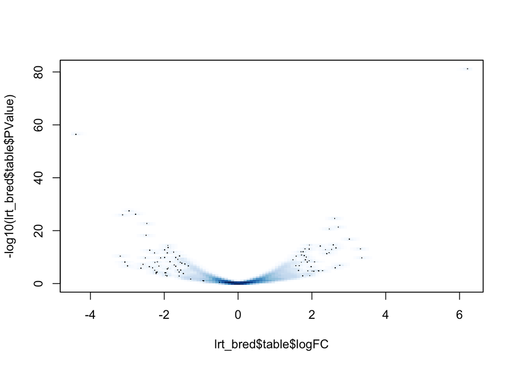

```r
smoothScatter(x=lrt_bred$table$logFC, y=-log10(lrt_bred$table$PValue))
```

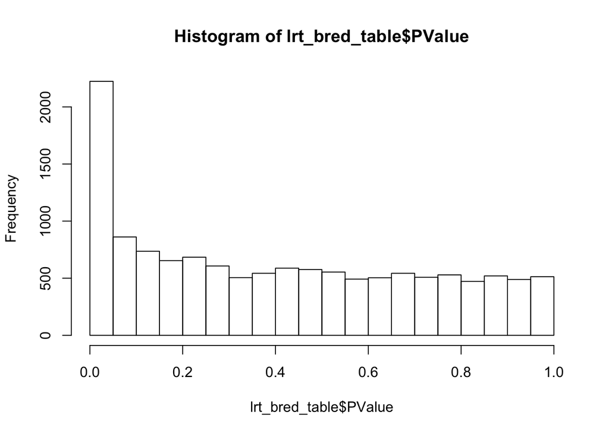

```r
lrt_bred_table = data.frame(lrt_bred$table, p.adjust(lrt_bred$table$PValue, method = "BH"))
colnames(lrt_bred_table) = c(colnames(lrt_bred$table), "adjPVal_BH")
hist(lrt_bred_table$PValue)
```

Format output into excel sheet.

```r
genes = rownames(counts3)
ensembl = useEnsembl(biomart="ensembl", dataset="mmusculus_gene_ensembl")
head(listAttributes(ensembl), 30)
```

```
##                               name
## 1                  ensembl_gene_id
## 2          ensembl_gene_id_version
## 3            ensembl_transcript_id
## 4    ensembl_transcript_id_version
## 5               ensembl_peptide_id
## 6       ensembl_peptide_id_version
## 7                  ensembl_exon_id
## 8                      description
## 9                  chromosome_name
## 10                  start_position
## 11                    end_position
## 12                          strand
## 13                            band
## 14                transcript_start
```

[output cut: 47 more lines]

```r
mmusculus_swissprot <- getBM(attributes=c('ensembl_gene_id','external_gene_name','description'),filters = 'ensembl_gene_id',  values = genes , mart = ensembl)

#fpkm_log_matrix2 = rpkm (y_for_DE_virus, gene.length=counts1[keep,"GeneLength"], log = TRUE)
index = match (genes, mmusculus_swissprot$ensembl_gene_id)
results = data.frame(mmusculus_swissprot[index,], counts3, fpkm_log_matrix, lrt_virus_table, lrt_bred_table)
colnames(results) = c(
                    colnames(mmusculus_swissprot[index,])
                  , unlist(lapply (colnames(counts3), function(x) paste(x, "counts", sep="_")))
                  , unlist(lapply (colnames(fpkm_log_matrix), function(x) paste(x, "fpkm", sep="_")))
                  , unlist(lapply (colnames(lrt_virus_table), function(x) paste(x, "_virus_KO_vs_WT_baseline", sep="_")))
                  , unlist(lapply (colnames(lrt_bred_table), function(x) paste(x, "_bred_KO_vs_WT_baseline", sep="_"))) )
curr_date = format(Sys.time(), "%a_%b_%d_%H_hrs_%M_min_%S_sec_%Y")
write.table(results, paste0("~/Documents/chang/chang_", curr_date, ".xls"), row.names=F, col.names=T, sep="\t")
```

Look at agreement between different analyses.

My analysis (edgeR): KO_vs_WT_virus1 KO_vs_WT_bred1

NovoGene’s analysis: KO_vs_WT_virus2 KO_vs_WT_bred2

```r
library(UpSetR)
upsetr_matrix  = data.frame(cbind(as.integer(results$adjPVal_BH__virus_KO_vs_WT_baseline<0.05), as.integer(results$adjPVal_BH__bred_KO_vs_WT_baseline<0.05), as.integer(counts1$padj.KO_virusvsWT_virus.< 0.05)[keep], as.integer(counts1$padj.KO_bredvsWT_bred. < 0.05)[keep]))
colnames(upsetr_matrix) = c ("KO_vs_WT_virus1", "KO_vs_WT_bred1", "KO_vs_WT_virus2", "KO_vs_WT_bred2")
#remove rows with one or more NA
upsetr_matrix2 = upsetr_matrix[which(complete.cases(upsetr_matrix)), ]
dim(upsetr_matrix)
```

```
## [1] 13102     4
```

```r
dim(upsetr_matrix2)
```

```
## [1] 13102     4
```

```r
colSums(upsetr_matrix2)
```

```
## KO_vs_WT_virus1  KO_vs_WT_bred1 KO_vs_WT_virus2  KO_vs_WT_bred2
##            1781             747            1736             702
```

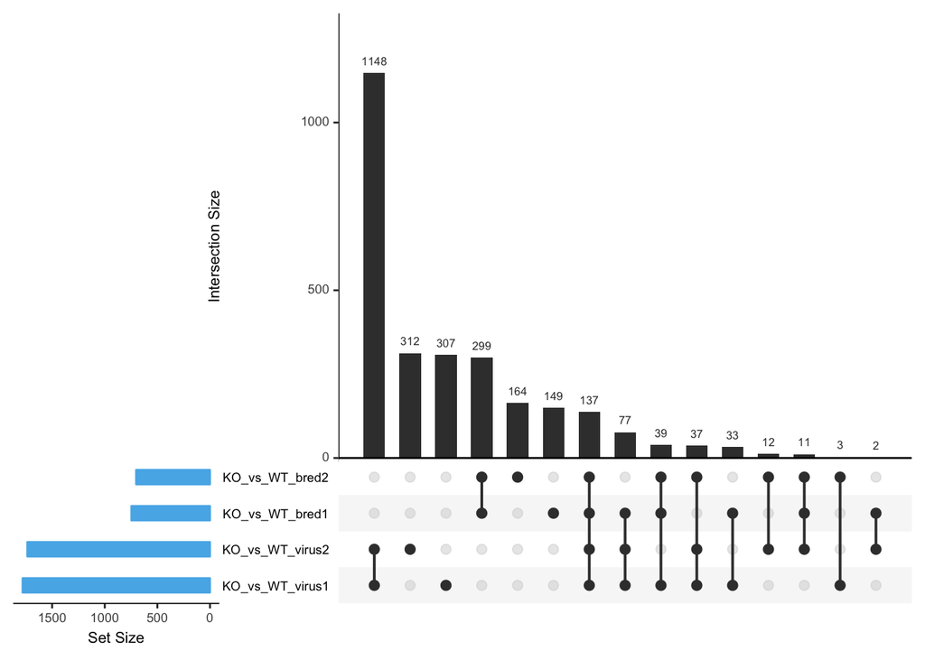

```r
upset(upsetr_matrix2, sets = c("KO_vs_WT_virus1", "KO_vs_WT_bred1",  "KO_vs_WT_virus2", "KO_vs_WT_bred2"),sets.bar.color = "#56B4E9", order.by = "freq", empty.intersections = "on")
```

Quick sanity check.

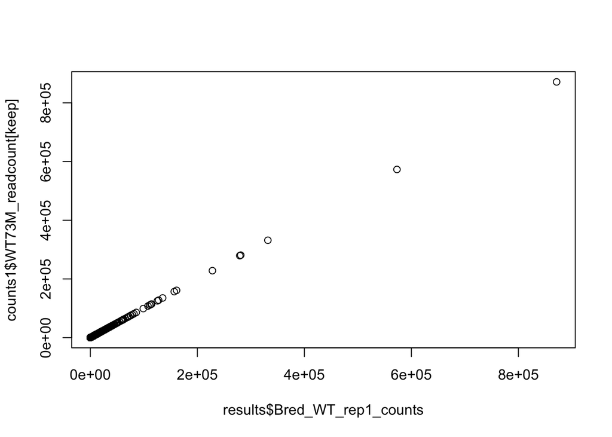

```r
#compare fpkm values  check
qqplot(results$Bred_WT_rep1_counts, counts1$WT73M_readcount[keep])
```

```r
cor(results$Bred_WT_rep1_counts, counts1$WT73M_readcount[keep])
```

```
## [1] 1
```

```r
cor(results$Bred_WT_rep1_fpkm, counts1$WT73M_fpkm[keep])
```

```
## [1] 1
```

```r
cor(results$Virus_WT_rep2_fpkm, counts1$WT113M_fpkm[keep])
```

```
## [1] 1
```

```r
cor(results$Virus_KO_rep2_fpkm, counts1$KO117M_fpkm[keep])
```

```
## [1] 1
```

Compare using Venn diagram.

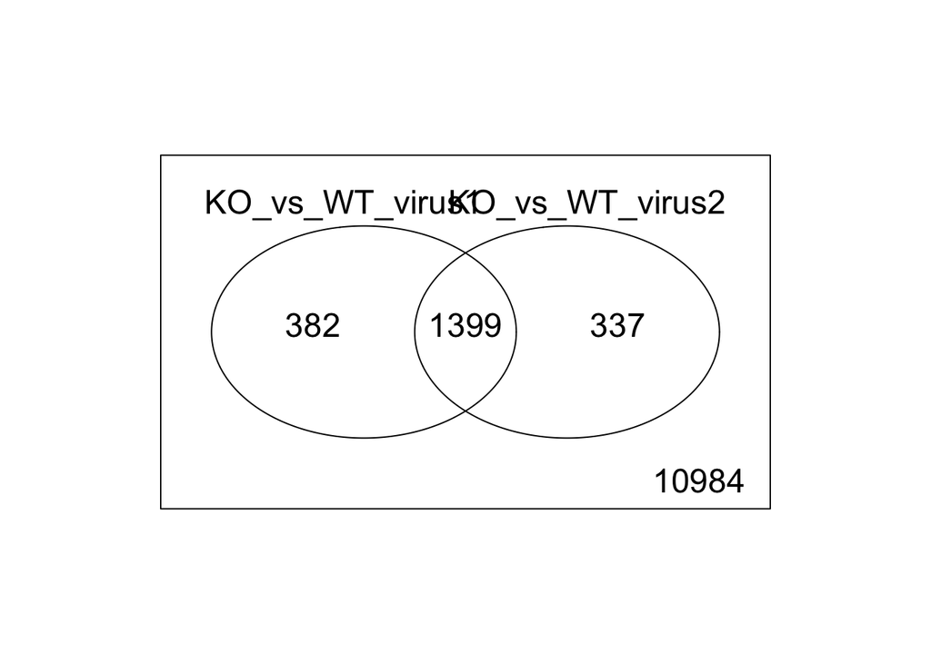

```r
library(limma)
venn1 = vennCounts(upsetr_matrix2[,c("KO_vs_WT_virus1", "KO_vs_WT_virus2" )])
vennDiagram(venn1)
```

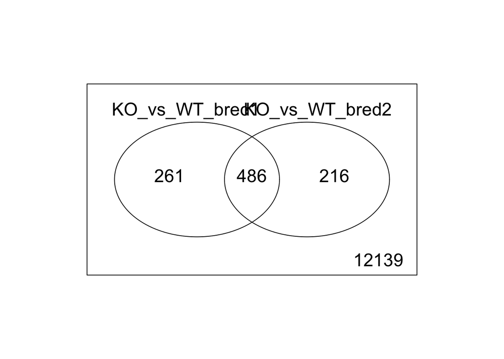

```r
venn2 = vennCounts(upsetr_matrix2[,c("KO_vs_WT_bred1", "KO_vs_WT_bred2")])
vennDiagram(venn2)
```

Try to use DEseq2 package(because that is what NovoGene used) : Virus KO vs WT

```r
library("DESeq2")
dds_virus <- DESeqDataSetFromMatrix(countData = counts3[, Virus_cols],
                              colData = cold [Virus_cols,],
                              design = ~ Condition2)
dds_virus
```

```
## class: DESeqDataSet
## dim: 13102 6
## metadata(1): version
## assays(1): counts
## rownames(13102): ENSMUSG00000028180 ENSMUSG00000028182 ...
##   ENSMUSG00000042675 ENSMUSG00000036959
## rowData names(0):
## colnames(6): Virus_WT_rep1 Virus_WT_rep2 ... Virus_KO_rep2
##   Virus_KO_rep3
## colData names(2): Condition1 Condition2
```

```r
dds_virus <- DESeq(dds_virus)
res_virus <- results(dds_virus)
res_virus
```

```
## log2 fold change (MLE): Condition2 KO vs WT
## Wald test p-value: Condition2 KO vs WT
## DataFrame with 13102 rows and 6 columns
##                            baseMean     log2FoldChange             lfcSE
##                           <numeric>          <numeric>         <numeric>
## ENSMUSG00000028180 584.531575009769 -0.048913850554096  0.15167582986856
## ENSMUSG00000028182 22.9055511127423 -0.528134983788081 0.441766434625783
## ENSMUSG00000028185 257.379732486516 -0.149040165051429 0.196106607312953
## ENSMUSG00000028184 1270.25067179793   0.39528980484451 0.124372676852894
## ENSMUSG00000028187 287.716427601086 0.0729313964812668  0.15048442628849
## ...                             ...                ...               ...
## ENSMUSG00000029587 129.918196071191   0.20571617056919 0.230814596326968
## ENSMUSG00000042670 413.326140449555 -0.173560786902053 0.145534118887493
## ENSMUSG00000042677 71.6198170086999 -0.121858800714154 0.351220116648219
## ENSMUSG00000042675 399.331015296532  0.365846679852173 0.187345955594155
## ENSMUSG00000036959 252.504431238365  0.581211062748994 0.220629591219855
##                                  stat              pvalue
##                             <numeric>           <numeric>
## ENSMUSG00000028180  -0.32248942100059   0.747081950857468
## ENSMUSG00000028182  -1.19550726898358   0.231888897927021
## ENSMUSG00000028185 -0.759995632444887    0.44725719556294
## ENSMUSG00000028184   3.17826885170328 0.00148157299559738
## ENSMUSG00000028187  0.484644147437899   0.627928791905352
## ...                               ...                 ...
## ENSMUSG00000029587  0.891261531301843   0.372788881090702
## ENSMUSG00000042670  -1.19257798946945   0.233034690261126
## ENSMUSG00000042677 -0.346958488246865   0.728622505353547
## ENSMUSG00000042675    1.9527866437891   0.050844881816713
## ENSMUSG00000036959   2.63432959983062 0.00843036074294119
##                                  padj
##                             <numeric>
## ENSMUSG00000028180  0.884535308163252
## ENSMUSG00000028182  0.485647113273631
## ENSMUSG00000028185  0.690698418352845
## ENSMUSG00000028184 0.0164924123944918
## ENSMUSG00000028187  0.814279999198276
## ...                               ...
## ENSMUSG00000029587  0.631092215105809
## ENSMUSG00000042670   0.48734565232263
## ENSMUSG00000042677  0.875537980841311
## ENSMUSG00000042675  0.194445312773664
## ENSMUSG00000036959 0.0575884183806129
```

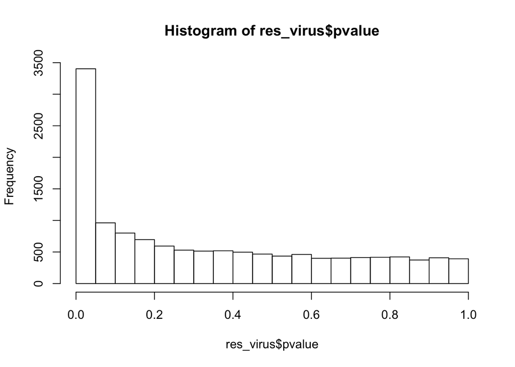

```r
hist(res_virus$pvalue)
```

Try to use DEseq2 : Bred KO vs WT

```r
dds_bred <- DESeqDataSetFromMatrix(countData = counts3[, Bred_cols],
                              colData = cold [Bred_cols,],
                              design = ~ Condition2)
dds_bred
```

```
## class: DESeqDataSet
## dim: 13102 6
## metadata(1): version
## assays(1): counts
## rownames(13102): ENSMUSG00000028180 ENSMUSG00000028182 ...
##   ENSMUSG00000042675 ENSMUSG00000036959
## rowData names(0):
## colnames(6): Bred_WT_rep1 Bred_WT_rep2 ... Bred_KO_rep2
##   Bred_KO_rep3
## colData names(2): Condition1 Condition2
```

```r
dds_bred <- DESeq(dds_bred)
res_bred <- results(dds_bred)
res_bred
```

```
## log2 fold change (MLE): Condition2 KO vs WT
## Wald test p-value: Condition2 KO vs WT
## DataFrame with 13102 rows and 6 columns
##                            baseMean       log2FoldChange             lfcSE
##                           <numeric>            <numeric>         <numeric>
## ENSMUSG00000028180 455.652409678798   -0.294117252987842 0.184476074890019
## ENSMUSG00000028182 21.8581963586387   -0.411655990456202 0.539605693059597
## ENSMUSG00000028185 307.246220282044    -0.62369584841559  0.22841699512714
## ENSMUSG00000028184 1669.29318156968   0.0536452755602652 0.189743241787682
## ENSMUSG00000028187 295.922613272988   0.0182560053011344  0.19954034864774
## ...                             ...                  ...               ...
## ENSMUSG00000029587 158.328208249405   0.0662363888616203  0.22250200911715
## ENSMUSG00000042670  285.72141367863   -0.252427186622131 0.294972122975536
## ENSMUSG00000042677 74.4376659797214    0.682741203861306 0.425587123356462
## ENSMUSG00000042675 544.428538027731 -0.00455331426721844 0.215465090236756
## ENSMUSG00000036959  314.91773345343    0.110994364643325 0.307212005726708
##                                   stat              pvalue
##                              <numeric>           <numeric>
## ENSMUSG00000028180   -1.59433819894091    0.11086030634298
## ENSMUSG00000028182   -0.76288296389552   0.445533197064855
## ENSMUSG00000028185   -2.73051419868488 0.00632356090936815
## ENSMUSG00000028184   0.282725619394091   0.777387175721195
## ENSMUSG00000028187  0.0914902946940463   0.927103017606344
## ...                                ...                 ...
## ENSMUSG00000029587    0.29768894727933   0.765940579984099
## ENSMUSG00000042670  -0.855766246910955   0.392127088598034
## ENSMUSG00000042677    1.60423369597453   0.108662549901798
## ENSMUSG00000042675 -0.0211324918677786   0.983139965915301
## ENSMUSG00000036959   0.361295660893095   0.717878437073241
##                                  padj
##                             <numeric>
## ENSMUSG00000028180  0.401877877045138
## ENSMUSG00000028182  0.744119212518486
## ENSMUSG00000028185 0.0798808131786162
## ENSMUSG00000028184  0.919004737480809
## ENSMUSG00000028187  0.976306437093944
## ...                               ...
## ENSMUSG00000029587  0.915159559667077
## ENSMUSG00000042670   0.70863084923603
## ENSMUSG00000042677  0.398806208898564
## ENSMUSG00000042675  0.994354405927811
## ENSMUSG00000036959  0.893315405606948
```

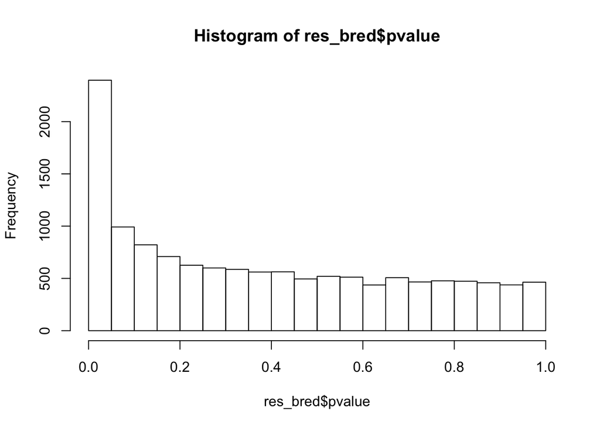

```r
hist(res_bred$pvalue)
```

The two DESeq2 analyses agree more which makes perfect sense. My analysis (edgeR): KO_vs_WT_virus1 KO_vs_WT_bred1

NovoGene’s analysis: KO_vs_WT_virus2 KO_vs_WT_bred2

My analysis (DESeq2): KO_vs_WT_virus3 KO_vs_WT_bred3

```r
library(UpSetR)
upsetr_matrix  = data.frame(cbind(as.integer(results$adjPVal_BH__virus_KO_vs_WT_baseline<0.05), as.integer(results$adjPVal_BH__bred_KO_vs_WT_baseline<0.05), as.integer(counts1$padj.KO_virusvsWT_virus.< 0.05)[keep], as.integer(counts1$padj.KO_bredvsWT_bred. < 0.05)[keep], as.integer(res_virus$padj<0.05), as.integer(res_bred$padj<0.05)))
colnames(upsetr_matrix) = c ("KO_vs_WT_virus1", "KO_vs_WT_bred1", "KO_vs_WT_virus2", "KO_vs_WT_bred2", "KO_vs_WT_virus3", "KO_vs_WT_bred3" )
#remove rows with one or more NA
upsetr_matrix2 = upsetr_matrix[which(complete.cases(upsetr_matrix)), ]
dim(upsetr_matrix)
```

```
## [1] 13102     6
```

```r
dim(upsetr_matrix2)
```

```
## [1] 12847     6
```

```r
colSums(upsetr_matrix2)
```

```
## KO_vs_WT_virus1  KO_vs_WT_bred1 KO_vs_WT_virus2  KO_vs_WT_bred2
##            1753             741            1726             702
## KO_vs_WT_virus3  KO_vs_WT_bred3
##            1797             769
```

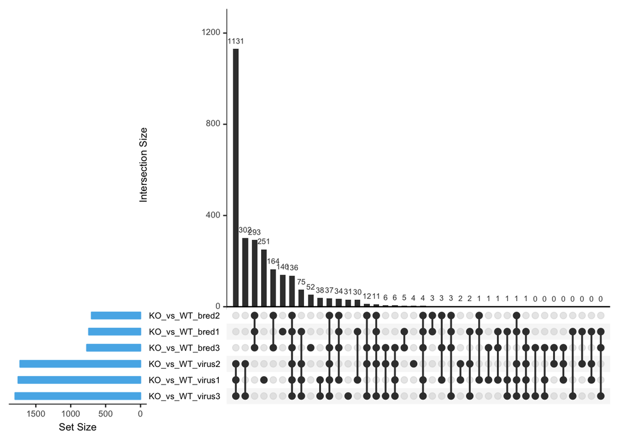

```r
upset(upsetr_matrix2, sets = c("KO_vs_WT_virus1", "KO_vs_WT_bred1",  "KO_vs_WT_virus2", "KO_vs_WT_bred2","KO_vs_WT_virus3", "KO_vs_WT_bred3"),sets.bar.color = "#56B4E9", order.by = "freq", empty.intersections = "on")
```

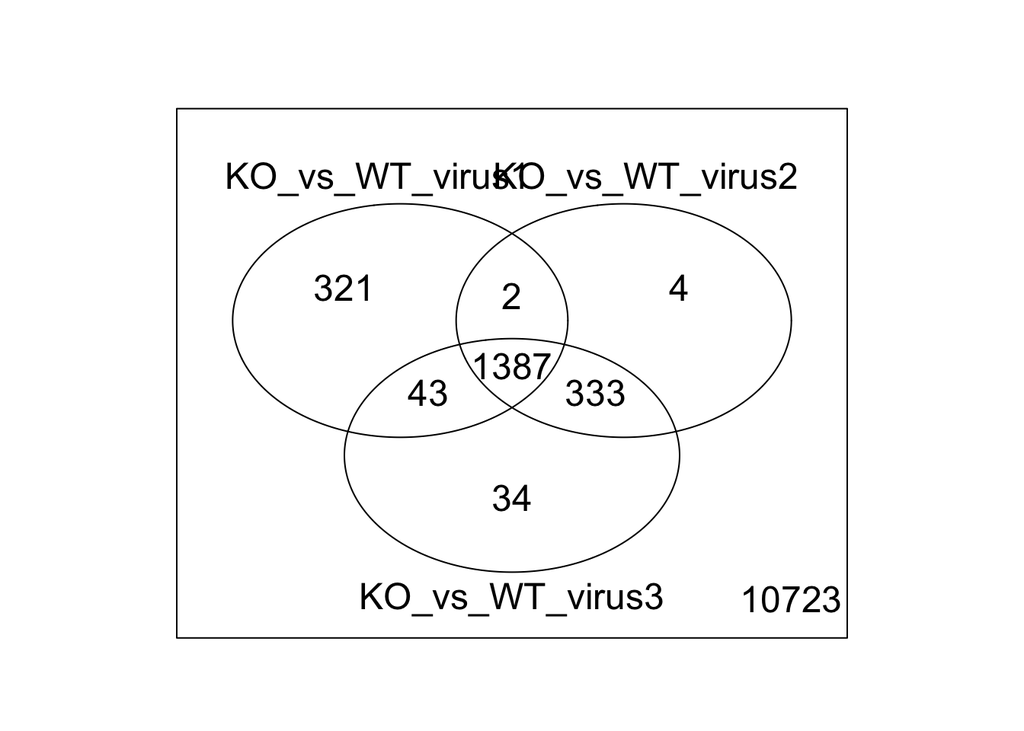

```r
venn1 = vennCounts(upsetr_matrix2[,c("KO_vs_WT_virus1", "KO_vs_WT_virus2", "KO_vs_WT_virus3" )])
vennDiagram(venn1)
```

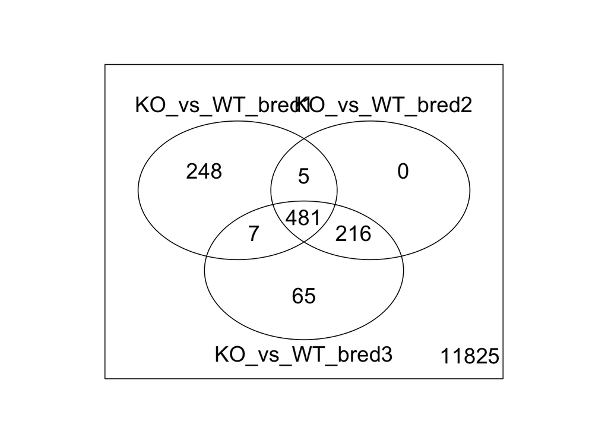

```r
venn2 = vennCounts(upsetr_matrix2[,c("KO_vs_WT_bred1", "KO_vs_WT_bred2", "KO_vs_WT_bred3")])
vennDiagram(venn2)
```

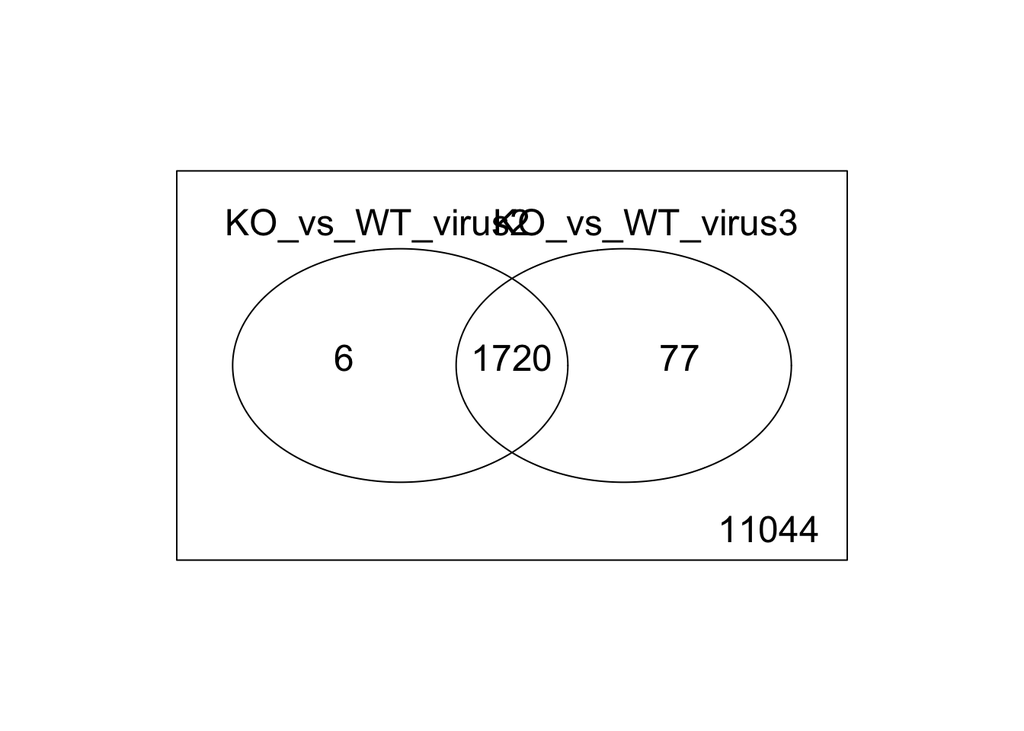

```r
venn3 = vennCounts(upsetr_matrix2[,c( "KO_vs_WT_virus2", "KO_vs_WT_virus3" )])
vennDiagram(venn3)
```

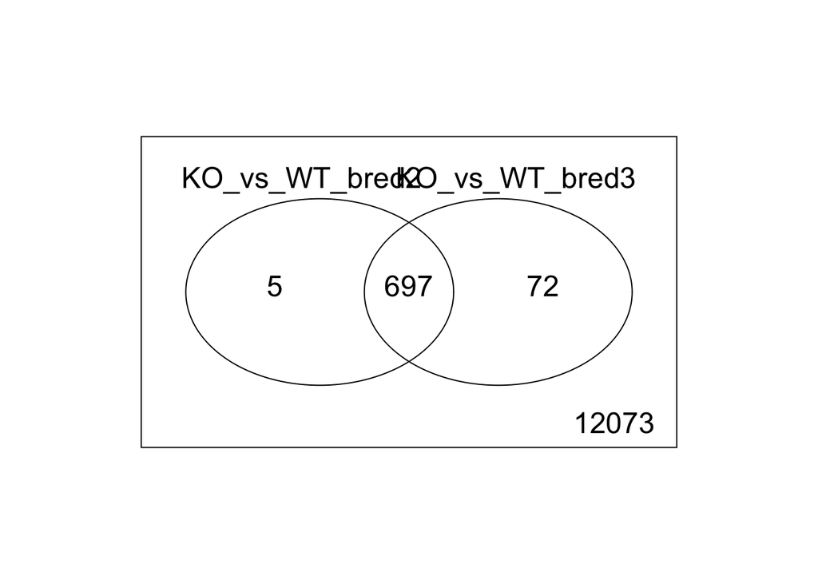

```r
venn4 = vennCounts(upsetr_matrix2[,c( "KO_vs_WT_bred2", "KO_vs_WT_bred3")])
vennDiagram(venn4)
```